← Advanced Engineering Mathematics

# Direction Fields and Euler's Method

## Real-World Scenario: Bacterial Growth in a Bioreactor

In whole cell modeling, we often encounter ODEs that describe how cellular quantities evolve over time -- metabolite concentrations, protein levels, or population sizes. Before solving these ODEs analytically, we can gain powerful geometric intuition by visualizing **direction fields** (slope fields) and computing approximate solutions via **Euler's method**.

We'll model bacterial population dynamics in a bioreactor where the growth rate depends on both the current population size and time (due to nutrient depletion). This gives us an ODE of the form $y' = f(t, y)$ that we can explore visually and numerically.

This notebook covers the key ideas from AEM Section 1.2:

- Geometric interpretation of $y' = f(x, y)$ as a slope at each point
- Direction fields (slope fields) and how they reveal solution behavior
- Isoclines -- curves of constant slope
- Euler's method for numerical approximation
- Error analysis: how step size affects accuracy

```python
import numpy as np
import matplotlib.pyplot as plt
import matplotlib as mpl

plt.style.use('seaborn-v0_8-whitegrid')
mpl.rcParams['font.family'] = 'DejaVu Sans'
```

## Key Formulas from AEM Section 1.2

**First-order ODE** (explicit form):

$$y' = f(x, y)$$

**Geometric meaning:** At every point $(x_0, y_0)$, the ODE prescribes a slope $f(x_0, y_0)$. A solution curve $y(x)$ passing through that point must have slope equal to $f(x_0, y_0)$ there:

$$y'(x_0) = f(x_0, y_0)$$

**Direction field:** A grid of short line segments (lineal elements) at points $(x, y)$, each with slope $f(x, y)$. Solution curves are tangent to these segments everywhere.

**Isoclines:** Curves along which $f(x, y) = c$ (constant). All lineal elements along an isocline have the same slope $c$.

**Euler's method:** Given $y(x_0) = y_0$ and step size $h$:

$$y_{n+1} = y_n + h \, f(x_n, y_n), \qquad x_{n+1} = x_n + h$$

Each step follows the tangent line at $(x_n, y_n)$ for a distance $h$.

## 1. Direction Fields -- Geometric Meaning of y' = f(x, y)

The derivative $y'$ is the slope of the solution curve. At every point $(x, y)$ in the plane, the ODE $y' = f(x, y)$ tells us *what slope a solution passing through that point must have*. By drawing short line segments with slope $f(x, y)$ at a grid of points, we build a **direction field** (or slope field).

Let's start with the textbook example: $y' = y + x$.

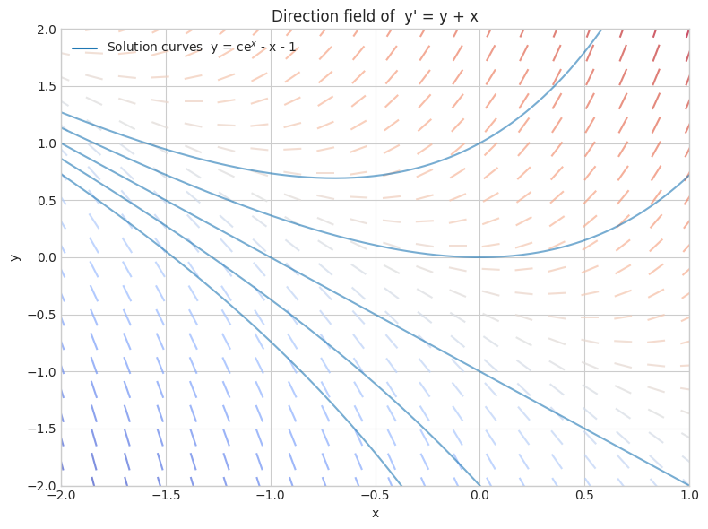

```python
def plot_direction_field(f, x_range, y_range, nx=20, ny=20, ax=None, title=None):
    """Plot a direction field for y' = f(x, y)."""
    if ax is None:
        fig, ax = plt.subplots(figsize=(8, 6))

    x = np.linspace(*x_range, nx)
    y = np.linspace(*y_range, ny)
    X, Y = np.meshgrid(x, y)
    slopes = f(X, Y)

    # Normalize arrows to unit length for uniform appearance
    U = np.ones_like(slopes)
    V = slopes
    N = np.sqrt(U**2 + V**2)
    U, V = U / N, V / N

    ax.quiver(X, Y, U, V, slopes, cmap='coolwarm', alpha=0.7,
              headwidth=0, headlength=0, headaxislength=0, pivot='middle',
              scale=35)
    ax.set_xlim(x_range)
    ax.set_ylim(y_range)
    ax.set_xlabel('x')
    ax.set_ylabel('y')
    if title:
        ax.set_title(title)
    return ax


# Example from the textbook (Fig. 7): y' = y + x
f_textbook = lambda x, y: y + x

fig, ax = plt.subplots(figsize=(8, 6))
plot_direction_field(f_textbook, (-2, 1), (-2, 2), ax=ax,
                     title="Direction field of  y' = y + x")

# Overlay exact solutions: y = ce^x - x - 1  (general solution)
x_fine = np.linspace(-2, 1, 200)
for c in [-2, -1, 0, 1, 2]:
    y_exact = c * np.exp(x_fine) - x_fine - 1
    mask = (y_exact > -2.5) & (y_exact < 2.5)
    ax.plot(x_fine[mask], y_exact[mask], 'C0', alpha=0.6, lw=1.5)

ax.plot([], [], 'C0', lw=1.5, label='Solution curves  y = ce$^x$ - x - 1')
ax.legend(loc='upper left')
plt.tight_layout()
plt.show()
```

The direction field reveals the structure of *all* solutions at once. Each short segment shows the slope that any solution passing through that point must have. The blue curves are exact solutions for different initial conditions -- notice how they are tangent to the field segments everywhere.

**Key insight:** The direction field exists regardless of whether we can solve the ODE analytically. For many ODEs, the field gives us qualitative understanding (growth, decay, oscillation, equilibria) even when no closed-form solution exists.

## 2. Isoclines

An **isocline** is a curve along which $f(x, y) = c$ (constant slope). All lineal elements along an isocline are parallel. This makes it easy to sketch direction fields by hand:

1. Set $f(x, y) = c$ for several values of $c$
2. Draw the resulting curves
3. Along each curve, draw segments with slope $c$

For $y' = y + x$, the isoclines are $y + x = c$, i.e., the lines $y = -x + c$.

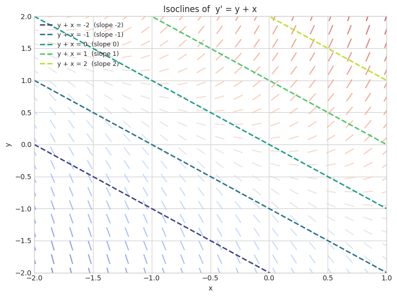

```python
fig, ax = plt.subplots(figsize=(8, 6))
plot_direction_field(f_textbook, (-2, 1), (-2, 2), ax=ax,
                     title="Isoclines of  y' = y + x")

# Isoclines: y + x = c  =>  y = -x + c
x_iso = np.linspace(-2, 1, 100)
colors_iso = plt.cm.viridis(np.linspace(0.2, 0.9, 5))
for c_val, col in zip([-2, -1, 0, 1, 2], colors_iso):
    y_iso = -x_iso + c_val
    mask = (y_iso > -2.5) & (y_iso < 2.5)
    ax.plot(x_iso[mask], y_iso[mask], '--', color=col, lw=2,
            label=f'y + x = {c_val}  (slope {c_val})')

ax.legend(loc='upper left', fontsize=9)
plt.tight_layout()
plt.show()
```

Along each dashed line, all the direction field segments have the same slope. The isocline $y + x = 0$ (the line $y = -x$) has slope 0 -- this is where solutions have horizontal tangents and transition from decreasing to increasing (or vice versa).

## 3. Bioreactor Example -- Direction Field for Logistic Growth

Now let's apply direction fields to our biotech scenario. Bacterial growth in a bioreactor with limited nutrients follows the **logistic ODE**:

$$\frac{dN}{dt} = r \, N \left(1 - \frac{N}{K}\right)$$

where:

- $N(t)$ = population (millions of cells)
- $r$ = intrinsic growth rate
- $K$ = carrying capacity (limited by nutrients and space)

This ODE is nonlinear -- the direction field will reveal equilibria and stability without us solving anything.

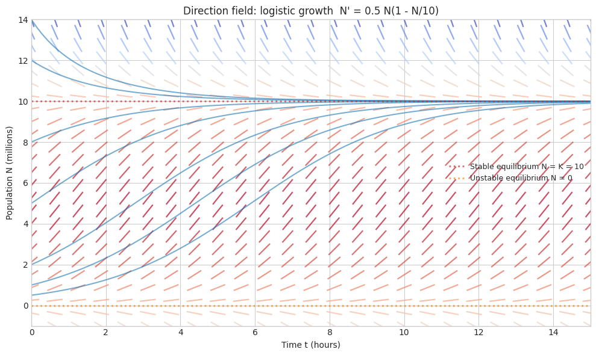

```python
# Logistic growth parameters
r = 0.5   # growth rate (per hour)
K = 10.0  # carrying capacity (millions of cells)

f_logistic = lambda t, N: r * N * (1 - N / K)

fig, ax = plt.subplots(figsize=(10, 6))
plot_direction_field(f_logistic, (0, 15), (-1, 14), nx=25, ny=25, ax=ax,
                     title="Direction field: logistic growth  N' = 0.5 N(1 - N/10)")

# Exact solution: N(t) = K / (1 + ((K - N0)/N0) * exp(-rt))
t_fine = np.linspace(0, 15, 300)
for N0 in [0.5, 1, 2, 5, 8, 12, 14]:
    if N0 == 0:
        continue
    N_exact = K / (1 + ((K - N0) / N0) * np.exp(-r * t_fine))
    ax.plot(t_fine, N_exact, 'C0', alpha=0.6, lw=1.5)

# Mark equilibria
ax.axhline(y=K, color='C3', ls=':', lw=2, alpha=0.7, label=f'Stable equilibrium N = K = {K:.0f}')
ax.axhline(y=0, color='C1', ls=':', lw=2, alpha=0.7, label='Unstable equilibrium N = 0')
ax.set_xlabel('Time t (hours)')
ax.set_ylabel('Population N (millions)')
ax.legend(loc='right', fontsize=9)
plt.tight_layout()
plt.show()
```

The direction field immediately reveals:

- **Two equilibria:** $N = 0$ (unstable) and $N = K = 10$ (stable)
- **Below $K$:** slopes are positive -- population grows
- **Above $K$:** slopes are negative -- population decreases back to $K$
- **All solutions converge to $K$** regardless of initial population (as long as $N_0 > 0$)

This qualitative analysis required no formula for the solution -- just the direction field!

## 4. Euler's Method

When we can't solve an ODE analytically, **Euler's method** gives us a simple numerical approximation. The idea is to follow the tangent line at each step:

$$y_{n+1} = y_n + h \cdot f(x_n, y_n)$$

Starting from the initial condition $(x_0, y_0)$, we step forward by $h$, using the slope $f(x_n, y_n)$ to estimate the next value.

Let's reproduce the textbook example (Table 1.1): $y' = y + x$, $y(0) = 0$, with step $h = 0.2$.

```python
def euler_method(f, x0, y0, h, n_steps):
    """Euler's method for y' = f(x, y), y(x0) = y0."""
    xs = np.zeros(n_steps + 1)
    ys = np.zeros(n_steps + 1)
    xs[0], ys[0] = x0, y0
    for i in range(n_steps):
        ys[i + 1] = ys[i] + h * f(xs[i], ys[i])
        xs[i + 1] = xs[i] + h
    return xs, ys


# Textbook example: y' = y + x,  y(0) = 0,  h = 0.2
h = 0.2
n_steps = 5
xs, ys = euler_method(f_textbook, x0=0, y0=0, h=h, n_steps=n_steps)

# Exact solution: y = e^x - x - 1  (with c=1 for y(0)=0)
y_exact_vals = np.exp(xs) - xs - 1
errors = y_exact_vals - ys

# Reproduce Table 1.1
print(f"{'n':>3}  {'x_n':>6}  {'y_n (Euler)':>12}  {'y(x_n) exact':>13}  {'Error':>8}")
print("-" * 50)
for i in range(n_steps + 1):
    print(f"{i:3d}  {xs[i]:6.1f}  {ys[i]:12.3f}  {y_exact_vals[i]:13.3f}  {errors[i]:8.3f}")
```

```
  n     x_n   y_n (Euler)   y(x_n) exact     Error
--------------------------------------------------
  0     0.0         0.000          0.000     0.000
  1     0.2         0.000          0.021     0.021
  2     0.4         0.040          0.092     0.052
  3     0.6         0.128          0.222     0.094
  4     0.8         0.274          0.426     0.152
  5     1.0         0.488          0.718     0.230
```

The errors grow with each step -- this is typical of Euler's method. Each step introduces a local error, and these errors accumulate. Let's visualize this.

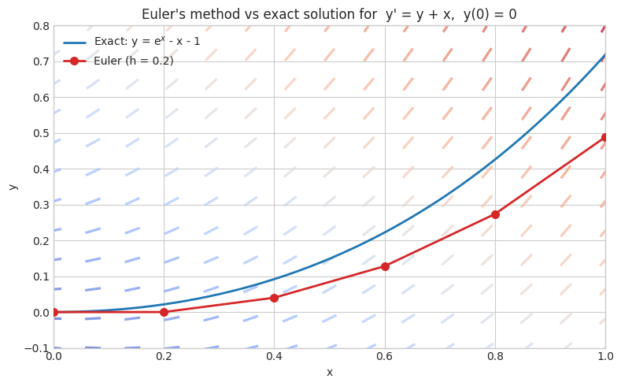

```python
fig, ax = plt.subplots(figsize=(8, 5))

# Direction field in background
plot_direction_field(f_textbook, (0, 1), (-0.1, 0.8), nx=15, ny=12, ax=ax,
                     title="Euler's method vs exact solution for  y' = y + x,  y(0) = 0")

# Exact solution
x_fine = np.linspace(0, 1, 200)
ax.plot(x_fine, np.exp(x_fine) - x_fine - 1, 'C0', lw=2, label='Exact: y = e$^x$ - x - 1')

# Euler steps
ax.plot(xs, ys, 'o-', color='C3', lw=2, ms=7, label=f'Euler (h = {h})', zorder=5)

# Show tangent lines at each step
for i in range(n_steps):
    slope = f_textbook(xs[i], ys[i])
    x_tang = np.array([xs[i], xs[i+1]])
    y_tang = ys[i] + slope * (x_tang - xs[i])
    ax.plot(x_tang, y_tang, '--', color='C3', alpha=0.4, lw=1)

ax.legend(fontsize=10)
ax.set_xlabel('x')
ax.set_ylabel('y')
plt.tight_layout()
plt.show()
```

## 5. Effect of Step Size on Euler's Method Accuracy

The accuracy of Euler's method depends critically on the step size $h$. Smaller $h$ means more steps but better accuracy. The global error is $O(h)$ -- halving the step size roughly halves the error.

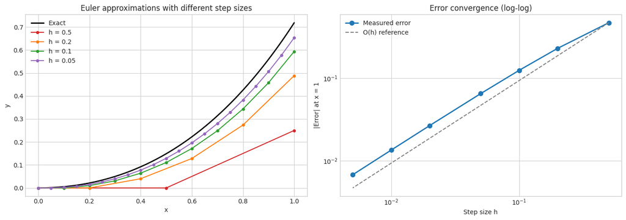

```python
fig, axes = plt.subplots(1, 2, figsize=(14, 5))

# Left: solutions for different step sizes
ax = axes[0]
x_fine = np.linspace(0, 1, 200)
ax.plot(x_fine, np.exp(x_fine) - x_fine - 1, 'k', lw=2, label='Exact')

step_sizes = [0.5, 0.2, 0.1, 0.05]
colors = ['C3', 'C1', 'C2', 'C4']
for h_val, col in zip(step_sizes, colors):
    n = int(1.0 / h_val)
    xs_h, ys_h = euler_method(f_textbook, 0, 0, h_val, n)
    ax.plot(xs_h, ys_h, 'o-', color=col, ms=4, lw=1.5, label=f'h = {h_val}')

ax.set_xlabel('x')
ax.set_ylabel('y')
ax.set_title('Euler approximations with different step sizes')
ax.legend()

# Right: error at x=1 vs step size (log-log)
ax = axes[1]
h_values = np.array([0.5, 0.2, 0.1, 0.05, 0.02, 0.01, 0.005])
errors_at_1 = []
for h_val in h_values:
    n = int(1.0 / h_val)
    xs_h, ys_h = euler_method(f_textbook, 0, 0, h_val, n)
    exact_at_1 = np.exp(1) - 1 - 1  # e - 2
    errors_at_1.append(abs(exact_at_1 - ys_h[-1]))

errors_at_1 = np.array(errors_at_1)
ax.loglog(h_values, errors_at_1, 'o-', color='C0', lw=2, ms=7, label='Measured error')
ax.loglog(h_values, h_values * errors_at_1[0] / h_values[0], '--', color='gray',
          lw=1.5, label='O(h) reference')
ax.set_xlabel('Step size h')
ax.set_ylabel('|Error| at x = 1')
ax.set_title('Error convergence (log-log)')
ax.legend()

plt.tight_layout()
plt.show()
```

The log-log plot confirms that Euler's method has **first-order convergence**: the error is proportional to $h$. The measured errors follow the $O(h)$ reference line. This means we need 10x more steps to gain one digit of accuracy -- a significant limitation that motivates higher-order methods (Runge-Kutta, etc.).

## 6. Euler's Method Applied to the Bioreactor

Let's use Euler's method to simulate bacterial growth in our bioreactor and compare with the exact logistic solution.

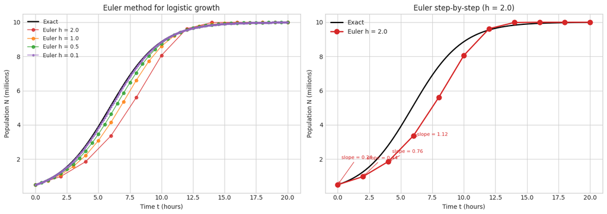

```python
# Simulate bioreactor growth with Euler's method
N0 = 0.5  # initial population: 0.5 million cells
t_end = 20  # hours

fig, axes = plt.subplots(1, 2, figsize=(14, 5))

# Exact logistic solution
t_fine = np.linspace(0, t_end, 300)
N_exact = K / (1 + ((K - N0) / N0) * np.exp(-r * t_fine))

# Left: Euler with different step sizes
ax = axes[0]
ax.plot(t_fine, N_exact, 'k', lw=2, label='Exact')

for h_val, col in zip([2.0, 1.0, 0.5, 0.1], ['C3', 'C1', 'C2', 'C4']):
    n = int(t_end / h_val)
    ts, Ns = euler_method(f_logistic, 0, N0, h_val, n)
    ax.plot(ts, Ns, 'o-', color=col, ms=3 if h_val < 0.5 else 5,
            lw=1.2, label=f'Euler h = {h_val}', alpha=0.8)

ax.set_xlabel('Time t (hours)')
ax.set_ylabel('Population N (millions)')
ax.set_title('Euler method for logistic growth')
ax.legend(fontsize=9)

# Right: step-by-step illustration with h = 2.0
ax = axes[1]
h_demo = 2.0
n_demo = int(t_end / h_demo)
ts_demo, Ns_demo = euler_method(f_logistic, 0, N0, h_demo, n_demo)

ax.plot(t_fine, N_exact, 'k', lw=2, label='Exact')
ax.plot(ts_demo, Ns_demo, 'o-', color='C3', lw=2, ms=8, label=f'Euler h = {h_demo}', zorder=5)

# Annotate first few steps
for i in range(min(4, n_demo)):
    slope = f_logistic(ts_demo[i], Ns_demo[i])
    ax.annotate(f'slope = {slope:.2f}',
                xy=(ts_demo[i], Ns_demo[i]),
                xytext=(ts_demo[i] + 0.3, Ns_demo[i] + 1.5 - 0.5 * i),
                fontsize=8, color='C3',
                arrowprops=dict(arrowstyle='->', color='C3', lw=0.8))

ax.set_xlabel('Time t (hours)')
ax.set_ylabel('Population N (millions)')
ax.set_title('Euler step-by-step (h = 2.0)')
ax.legend()

plt.tight_layout()
plt.show()
```

## 7. Gallery: Direction Fields for Different ODE Types

Direction fields look different depending on the ODE's structure. Let's compare several types to build intuition.

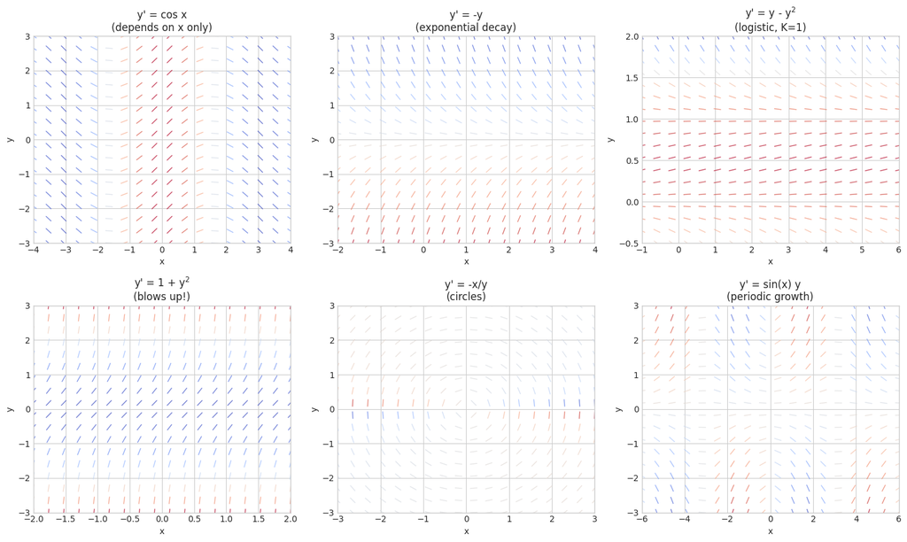

```python
odes = [
    (lambda x, y: np.cos(x),       "y' = cos x\n(depends on x only)",     (-4, 4), (-3, 3)),
    (lambda x, y: -y,              "y' = -y\n(exponential decay)",         (-2, 4), (-3, 3)),
    (lambda x, y: y - y**2,        "y' = y - y$^2$\n(logistic, K=1)",     (-1, 6), (-0.5, 2)),
    (lambda x, y: 1 + y**2,        "y' = 1 + y$^2$\n(blows up!)",         (-2, 2), (-3, 3)),
    (lambda x, y: -x / (y + 1e-10), "y' = -x/y\n(circles)",              (-3, 3), (-3, 3)),
    (lambda x, y: np.sin(x) * y,   "y' = sin(x) y\n(periodic growth)",   (-6, 6), (-3, 3)),
]

fig, axes = plt.subplots(2, 3, figsize=(15, 9))
for ax, (f_ode, title, xr, yr) in zip(axes.flat, odes):
    plot_direction_field(f_ode, xr, yr, nx=18, ny=18, ax=ax, title=title)

plt.tight_layout()
plt.show()
```

## 8. When Euler's Method Fails: Stiff and Blow-up Cases

Euler's method can fail spectacularly for certain ODEs. Let's see two failure modes.

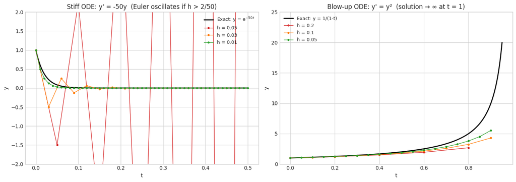

```python
fig, axes = plt.subplots(1, 2, figsize=(14, 5))

# Case 1: Stiff ODE  y' = -50y,  exact solution y = e^{-50t}
# With h too large, Euler oscillates wildly
ax = axes[0]
f_stiff = lambda t, y: -50 * y
t_fine = np.linspace(0, 0.5, 300)
ax.plot(t_fine, np.exp(-50 * t_fine), 'k', lw=2, label='Exact: y = e$^{-50t}$')

for h_val, col in zip([0.05, 0.03, 0.01], ['C3', 'C1', 'C2']):
    n = int(0.5 / h_val)
    ts, ys_stiff = euler_method(f_stiff, 0, 1, h_val, n)
    ax.plot(ts, ys_stiff, 'o-', color=col, ms=3, lw=1, label=f'h = {h_val}')

ax.set_xlabel('t')
ax.set_ylabel('y')
ax.set_title("Stiff ODE: y' = -50y  (Euler oscillates if h > 2/50)")
ax.set_ylim(-2, 2)
ax.legend(fontsize=9)

# Case 2: Blow-up ODE  y' = y^2,  exact solution y = 1/(1-t), blows up at t=1
ax = axes[1]
f_blowup = lambda t, y: y**2
t_fine = np.linspace(0, 0.95, 200)
ax.plot(t_fine, 1 / (1 - t_fine), 'k', lw=2, label='Exact: y = 1/(1-t)')

for h_val, col in zip([0.2, 0.1, 0.05], ['C3', 'C1', 'C2']):
    n = int(0.95 / h_val)
    ts, ys_blow = euler_method(f_blowup, 0, 1, h_val, n)
    # Clip for display
    mask = ys_blow < 30
    ax.plot(ts[mask], ys_blow[mask], 'o-', color=col, ms=3, lw=1, label=f'h = {h_val}')

ax.set_xlabel('t')
ax.set_ylabel('y')
ax.set_title("Blow-up ODE: y' = y²  (solution → ∞ at t = 1)")
ax.set_ylim(0, 25)
ax.legend(fontsize=9)

plt.tight_layout()
plt.show()
```

**Left (Stiff ODE):** For $y' = -50y$, Euler's method requires $h < 2/|{-50}| = 0.04$ for stability. With $h = 0.05 > 0.04$, the approximation oscillates with growing amplitude -- even though the true solution decays smoothly. This is the **stiffness** problem: fast dynamics demand tiny step sizes.

**Right (Blow-up):** For $y' = y^2$, the exact solution $y = 1/(1-t)$ goes to infinity at $t = 1$. Euler's method lags behind the true solution -- it always underestimates because the slope is increasing faster than it can keep up. No finite step size can track a blow-up.